# Code

## 1 Data Preprocessing

Before we load the data, we should preprocess the dataset, because the size of dataset is not big enough for training the model with best performance.

To prevent the original dataset being modified, we need to create an image_pre folder and a mask_pre folder to save the preprocessing data.

We flip the images and rotate the images within 15 degrees, because we noticed that all the MR images are upwards, only with different degrees, therefore, we just flip the images and rotate them with small degrees.

```python
from glob import glob
import os
from torchvision import transforms
from PIL import Image
import cv2
```

```python
def pre_processing(path):
    """
    The function to preprocessing the dataset
    :param path: The root path of the training set.
    :return: True if successive
    """

    img_files = glob(os.path.join(path, 'image', '*.png'))  # search every paths of all images in the image folder
    mask_files = []  # mask_files is saving the paths of all masks

    # Save every masks path for corresponding images.
    for img_path in img_files:
        basename = os.path.basename(img_path)
        mask_files.append(os.path.join(path, 'mask', basename[:-4] + '_mask.png'))

    # Empty the image_pre and mask_pre folders.
    empty_folder(os.path.join(path, 'image_pre'))
    empty_folder(os.path.join(path, 'mask_pre'))

    # Instantiate the horizontal flip, because p=1, every image would be flipped horizontally.
    transformflp = transforms.RandomHorizontalFlip(p=1)

    # For each image and its corresponding mask, we flip horizontally and rotate them within 15 degrees.
    for index in range(len(img_files)):

        # Open the image and mask.
        img = Image.open(img_files[index])
        mask = Image.open(mask_files[index])

        # Flip the image and mask.
        img_flp = transformflp(img)
        mask_flp = transformflp(mask)

        basename = os.path.basename(img_files[index])  # get the filename in order to save the files.

        # Rotate the image and mask with different degrees, and save them.
        for i in range(3):
            if i == 1:
                 continue
            img.rotate(15 - i * 15).save(os.path.join(path, 'image_pre', basename[:-4] + '_rotate_' + str(i) + '.png'))
            img_flp.rotate(15 - i * 15).save(
                os.path.join(path, 'image_pre', basename[:-4] + '_flip_rotate_' + str(i) + '.png'))
            mask.rotate(15 - i * 15).save(
                os.path.join(path, 'mask_pre', basename[:-4] + '_rotate_' + str(i) + '_mask.png'))
            mask_flp.rotate(15 - i * 15).save(
                os.path.join(path, 'mask_pre', basename[:-4] + '_flip_rotate_' + str(i) + '_mask.png'))

        # Save the original image and mask to the preprocessing folders.
        img.save(os.path.join(path, 'image_pre', basename[:-4] + '.png'))
        img_flp.save(os.path.join(path, 'image_pre', basename[:-4] + '_flip.png'))

        # Save the flipped image and mask.
        mask.save(os.path.join(path, 'mask_pre', basename[:-4] + '_mask.png'))
        mask_flp.save(os.path.join(path, 'mask_pre', basename[:-4] + '_flip_mask.png'))

        # Equalize the histogram to make the comtrast more clear.
        equalizehist(path)
    return True

def equalizehist(path):
    """
    The function to equalize the histogram of the image.
    :param path: The folder where the images are.
    :return: True if successive
    """

    img_path_list = glob.glob(os.path.join(path, 'mask_pre','*.png'))
    for img_path in img_path_list:
        img = cv2.imread(img_files[index], cv2.IMREAD_UNCHANGED)
        img = cv2.equalizeHist(img)
        cv2.imwrite(img_path, img)

    return True

def empty_folder(path):
    """
    The function to empty the folder.
    :param path: The folder which you want to empty.
    :return: True if successive
    """

    # Save the paths of all images in this folder.
    files = glob(os.path.join(path, '*.png'))
    for i in files:
        os.remove(i)

    return True
```

```python
Run the preprocessing.
pre_processing(r'./data/train/')
```

## 2 Define a segmentation model with Pytorch

### 2.1 Load the Dataset

Basically, we used the dataload from the tutorial file, but change the reading folder from './image/' to './image_pre/', same as the mask folder.

```python
import torch.utils.data as data
import numpy as np
```

```python
class TrainDataset(data.Dataset):
    def __init__(self, root='', train = True):
        super(TrainDataset, self).__init__()
        if train == True:
            img_folder = 'image_pre'
            mask_folder = 'mask_pre'
        else:
            img_folder = 'image'
            mask_folder = 'mask'
        self.img_files = glob(os.path.join(root, img_folder, '*.png'))
        self.mask_files = []
        for img_path in self.img_files:
            basename = os.path.basename(img_path)

            self.mask_files.append(os.path.join(root, mask_folder, basename[:-4] + '_mask.png'))

    def __getitem__(self, index):
        img_path = self.img_files[index]
        mask_path = self.mask_files[index]
        data = cv2.imread(img_path, cv2.IMREAD_UNCHANGED)
        data = np.array([data, data, data])
        label = cv2.imread(mask_path, cv2.IMREAD_UNCHANGED)
        return torch.from_numpy(data).float(), torch.from_numpy(label).float()

    def __len__(self):
        return len(self.img_files)


class TestDataset(data.Dataset):
    def __init__(self, root=''):
        super(TestDataset, self).__init__()
        self.img_files = glob(os.path.join(root, 'image', '*.png'))

    def __getitem__(self, index):
        img_path = self.img_files[index]
        data = cv2.imread(img_path, cv2.IMREAD_UNCHANGED)
        data = np.array([data, data, data])
        return torch.from_numpy(data).float()

    def __len__(self):
        return len(self.img_files)
```

### 2.2 Define a Segmenatation Mode

Here, we use deeplabv3_resnet50 as our network architecture and trying use cuda to run this for effeciency.

Again, because the size of our dataset is small, it is a great way to use pretrain for our model to have better performance.

```python
import torch
device = torch.device('cuda' if torch.cuda.is_available() else "cpu")  # set the device.
num_classes = 4  # number of classes for segmenatation
pretrain = True  # we will use pretrain soon
```

```python
# Here we use the model from pytorch.
# We did not use the pretrain in this model because the number of class in this pretrain model
# is 21 (including background), but we just have 4 classes, so we cannot use its pretrain setting.
# We will modify the pretrain model later.
def create_model():
    """
    The function to create the model.
    :return: created model
    """

    model = torch.hub.load('pytorch/vision:v0.10.0', 'deeplabv3_resnet50', pretrained=False, num_classes=num_classes, aux_loss=True)
    model.to(device)

    # pretrain module
    model = pre_train(model, pretrain=True)
    return model
```

```python
# Pretrain module
def pre_train(model, pretrain=False):
    """
    The function to use the pretrain weights.
    :param model: model to be added weights
    :param pretrain: True when pretrain applys
    :return: model added the pretrain weights
    """

    if pretrain:
        # We downloaded the resnet50 from the official website.
        # "deeplabv3_resnet50_coco": "https://download.pytorch.org/models/deeplabv3_resnet50_coco-cd0a2569.pth"
        weights_dict = torch.load("./deeplabv3_resnet50_coco.pth", map_location='cpu')

        # As we said before, the number of classes in this pretrain model is 21.
        # We need to delete the weights about the classifier to ensure the shape of the weights is same.
        if num_classes != 21:
            for k in list(weights_dict.keys()):
                if "classifier.4" in k:
                    del weights_dict[k]

        # Load the pretrain model.
        model.load_state_dict(weights_dict, strict=False)
    return model
```

### 2.3 Define a Loss Function

Here we used the Dice+CE loss function. Its dice function use Laplace smoothing, which is adding one on both numerator and denominator sides. It can reduce the probability of overfiting, because it can make the coefficient get greater and make the loss be smaller, therefore the convergence will be happened sooner.

```python
import torch.nn as nn
import torch.nn.functional as F
class DiceCELoss(nn.Module):
    def __init__(self, weight=None, size_average=True):
        super(DiceCELoss, self).__init__()

    def forward(self, inputs, targets, smooth=1):
        """
        The forward function of Dice+CE loss.
        :param inputs: The mask which is produced by images.
        :param targets: The mask which is given.
        :param smooth: The smooth variable to prevent the denominator be zero
                       and to reduce the probability of overfitting
        :return: the sum of main loss and aux loss.
        """

        losses = {}
        targets_view = targets.view(-1)  # expand the target to 1-dimension

        # for main classifier and aux classifier separately
        for name, x in inputs.items():

            # expland the input image to 1-dimension
            x_view = x.argmax(1)
            x_view = x_view.view(-1)

            dice_loss = 0.0

            # for each classes
            for i in range(4):
                tmp_1 = (x_view == i).float()  # find all pixals in input image which is belong to current class
                tmp_2 = (targets_view == i).float()  # find all pixals in output image which is belong to current class
                intersection = (tmp_1 * tmp_2).sum()  #  the intersection of tmp_1 and tmp_2
                dice_loss += 1 - (2. * intersection + smooth) / (tmp_1.sum() + tmp_2.sum()+ smooth)  # calculate the dice loss with smooth for this class
            dice_loss_avg = dice_loss / 4.  # calculate the average dice loss
            CE = F.cross_entropy(x, targets.long())  # calculate the cross-entropy
            Dice_CE = CE + dice_loss_avg  # sum of cross entropy and dice loss

            losses[name] = Dice_CE  # save to the current classifier

        # if there is only main classifier
        if len(losses) == 1:
            return losses['out']

        return losses['out'] + 0.5 * losses['aux']
```

```python
# Instantiate the loss function.
def create_loss_function():
    """
    The function to create the loss function.
    :return: loss function created
    """

    loss_func = DiceCELoss()
    loss_func.to(device)
    return loss_func
```

### 2.4 Define a Optimizer Function

Here we used AdamW optimizer.

```python
aux = True  # Use aux optimizer or not.
init_lr = 0.01  # Set inintial learning rate.

def create_optimizer(model,init_lr, aux=True):
    """
    The function to create optimizer.
    :param model: model to be added weights
    :param init_lr: initial learning rate
    :param aux: True if using aux optimizer
    :return: optimizer
    """

    # Set optimizer parameters.
    params_to_optimize = [
        {"params": [p for p in model.backbone.parameters() if p.requires_grad]},
        {"params": [p for p in model.classifier.parameters() if p.requires_grad]}
    ]
    if aux:  # if use aux optimizer
        params = [p for p in model.aux_classifier.parameters() if p.requires_grad]
        params_to_optimize.append({"params": params, "lr": init_lr*10})

    # Use AdamW as our optimizer.
    optimizer = torch.optim.AdamW(
        params_to_optimize,
        lr=init_lr, weight_decay=1e-4
    )
    return optimizer
```

### 2.5 Learning Rate

We use learning rate scheduler here. The method we used is stepLR.

```python
def create_lr_scheduler(optimizer):
    """
    The function to create learning rate scheduler.
    :param optimizer: optimizer used
    :return: learning rate scheduler
    """

    # Create the learning rate scheduler.
    lr_scheduler = torch.optim.lr_scheduler.StepLR(optimizer=optimizer, step_size=10, gamma=0.995)
    return lr_scheduler
```

### 2.6 Initialize the Training

We need to initialize the model, loss function, optimizer and lr_schedule because we want that the initial conditions for each training are same.

```python
def init(init_lr):
    """
    The function to initialize model, loss function, optimizer and lr_scheduler.
    :param init_lr: initial learning rate
    :return: model, loss function, optimizer, lr_scheduler
    """

    model = create_model()
    loss_func = create_loss_function()
    optimizer = create_optimizer(model,init_lr, aux=True)
    lr_scheduler = create_lr_scheduler(optimizer)
    return model, loss_func, optimizer, lr_scheduler
```

### 2.7 Testing Function

Use the current model to predict the masks of validatiation dataset and then calculate their overall dice and dices for separate classes.

```python
def categorical_dice(mask1, mask2, label_class=1):
    """
    Dice score of a specified class between two volumes of label masks.
    (classes are encoded but by label class number not one-hot )
    Note: stacks of 2D slices are considered volumes.

    Args:
        mask1: N label masks, numpy array shaped (H, W, N)
        mask2: N label masks, numpy array shaped (H, W, N)
        label_class: the class over which to calculate dice scores

    Returns:
        volume_dice
    """

    mask1_pos = (mask1 == label_class).float()
    mask2_pos = (mask2 == label_class).float()
    dice = 2 * (mask1_pos * mask2_pos).sum() / (mask1_pos.sum() + mask2_pos.sum())
    return dice
```

```python
def evaluate(model, data_loader, device, num_classes):
    """
    Predict the masks of validation datasets by using current model and calculate the overall dice and dices for separate classes.
    :param model: current model and weights
    :param data_loader: the data_loader should contain validation data
    :param device: device to run current programme
    :param num_classes: number of classes needed to be segmented
    :return: overall dice and dices for each class
    """

    dice_avg = 0.
    dice_class = [0., 0., 0., 0.]

    model.eval()  # model evaluate mode, will not change the weight of the model

    # Stop gradient calculatation to accelerate the calculation and save video memory.
    with torch.no_grad():

        # for the images and corresponding masks of each batch in the validation dataloader
        for image, target in data_loader:
            image, target = image.to(device), target.to(device)  # move the work to the current device

            # output the prediction mask for current image
            output = model(image)
            output = output['out']

            output = output.argmax(1).squeeze(0)  # regularation to the same format with the original mask
            dice = 0.

            # for each of classes
            for i in range(num_classes):
                dice_class[i] += categorical_dice(output, target, i) # calculate the dice for each class

                # if the current class is not background, add its dice to the variable which will to be used to calculate the overall dice later.
                if i != 0:
                    dice += categorical_dice(output, target, i)

            dice /= 3.  # calculate the overall dice
            # print(dice)
            dice_avg += dice

    cnt = len(data_loader)
    dice_avg /= cnt  # get the overall dice
    for i in range(num_classes):
        dice_class[i] = dice_class[i].item() / cnt  # get the dice for each class
    return dice_avg, dice_class
```

### 2.8 Training

Now, we are going to train our model.

```python
from torch.utils.data import DataLoader
import datetime
def training(optimizer, lr_scheduler, epoch_num, batch_size, if_show=True):
    """
    Training the model with the training set.
    :param optimizer: the optimizer used
    :param lr_scheduler: the learning scheduler used
    :param epoch_num: maximum number of epoches
    :param batch_size: number of images in one batch
    :param if_show: show the print text or not, default: True
    :return: text file name
    """

    # Create a txt file to record the data.
    txt_name = "results{}.txt".format(datetime.datetime.now().strftime("%Y%m%d-%H%M%S"))
    f = open(txt_name, 'w+')  # create the file


    # Set some variables for loading datas.
    num_workers = 0  # number of threads, set to 0 because it may crush when using cuda on Windows

    # Load the training set.
    train_data_path = './data/train'
    train_set = TrainDataset(train_data_path, train= True)
    train_data_loader = DataLoader(dataset=train_set, num_workers=num_workers, batch_size=batch_size, shuffle=True)

    # Load the validation set.
    val_data_path = './data/val'
    val_set = TrainDataset(val_data_path, train= False)
    val_data_loader = DataLoader(dataset=val_set, num_workers=num_workers, batch_size=1, shuffle=True)


    # Start the training module.
    for epoch in range(epoch_num):

        loss_avg = 0.  # the variable to save the loss

        model.train()  # model to training mode

        if if_show:
            print('Epoch[{}] start:'.format(epoch))

        # for the images and masks of each batch in the training data loader
        for image, target in train_data_loader:
            image, target = image.to(device), target.to(device)

            # calculate the loss
            output = model(image)
            loss = loss_func(output, target)

            optimizer.zero_grad()  # Initial the gradient of optimizer to be zero.
            loss.backward()  # backward propagation
            optimizer.step()  # update the weights of optimizer
            lr_scheduler.step()  # update the learning rate scheduler
            lr = optimizer.param_groups[0]["lr"]  # update the learning rate
            loss_avg += loss.item()  # add to the loss

        loss_avg /= 1. * len(train_data_loader.dataset) / batch_size  # calculate the average loss for each image

        # Calculate the validation overall dice and dice for each class.
        val_dice, val_dice_class = evaluate(model, val_data_loader, device, num_classes)

        print_txt = 'epoch[{}/{}], train loss={}, val dice={}, val dice class={}, lr={}'.format(epoch, epoch_num-1, loss_avg, val_dice,
                                                                                      val_dice_class, lr)
        if if_show:
            print(print_txt)
        f.write(print_txt + '\n')  # record the info into the text file

        # Save the model
        save_file = {
          "model": model.state_dict(),
          "epoch": epoch,
        }
#         torch_path = r'./models/model_' + str(epoch) + ".pth"
        torch_path = r'./models/model_' + str(epoch) + ".pth"
        torch.save(save_file, torch_path)

    f.close()  # close the recording text file
    return txt_name
```

```python
epoch_num = 200
```

### 2.9 Compare Parameters

We could use different optimizers, learning rate schedulers, loss functions, and different hyperparameters for training. Here we try different ways and values with respect to each of them and compare the dice score performance on the validation set.

```python
import re


def get_loss_dice(txtpath):
    """
    From the record, get the training loss and validation dice.
    :param txtpath: record text file path
    :return: training loss and validation dice
    """

    f = open(txtpath, 'r')  # open the file, read-only
    train_loss = []  # variable for saving training loss
    val_dice = []   # variable for saving validation loss

    # read the text file line by line
    for line in f:
        current_train_loss = re.findall(r'train loss=(.*?),', line)[0]  # get the train loss data
        train_loss.append(float(current_train_loss))

        current_val_dice = re.findall(r'val dice=(.*?),', line)[0]  # get the validation data
        val_dice.append(float(current_val_dice))
    f.close()  # close the text file
    return train_loss, val_dice
```

#### 2.9.1 Batch Size Experiment

Since an epoch is often too large for the computer to load, we will divide it into several smaller batches, while batch size is the number of training samples in each batch. It could determine the speed and accuracy of convergence. Too small value leads the speed of convergence too slow, while too large value may disturb the direction and accuracy of convergence. What else we need to consider is the memory efficiency and memory capacity, and find the best balance between them. Here we try different value from 2 to 10 for batch size and show the validation result for each of them.

```python
# Create different batch size list for experiment
batch_size_list = [2, 4, 6, 8, 10]
# Record the validation dice socre for each value of batch size of training
log_file_list = []
for batch_size in batch_size_list:
    model, loss_func, optimizer, lr_scheduler = init(init_lr)
    file = training(optimizer, lr_scheduler, epoch_num, batch_size, if_show=False)
    log_file_list.append(file)
```

```
Using cache found in C:\Users\quchenyuan/.cache\torch\hub\pytorch_vision_v0.10.0
Using cache found in C:\Users\quchenyuan/.cache\torch\hub\pytorch_vision_v0.10.0
Using cache found in C:\Users\quchenyuan/.cache\torch\hub\pytorch_vision_v0.10.0
Using cache found in C:\Users\quchenyuan/.cache\torch\hub\pytorch_vision_v0.10.0
Using cache found in C:\Users\quchenyuan/.cache\torch\hub\pytorch_vision_v0.10.0
```

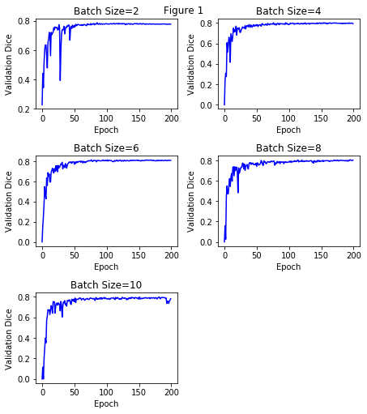

```python
import matplotlib.pyplot as plt
import math
log_file_list = glob(os.path.join('./txt_path','*.txt'))
batch_size_list = [2, 4, 6, 8, 10]
# Plot the validation dice score with epoch for each batch size figure
plt.figure(figsize=(6.4,2.4*math.ceil(len(batch_size_list)/2)))
plt.suptitle('Figure 1')
for idx, i in enumerate(batch_size_list):

    plt.subplot(math.ceil(len(batch_size_list)/2), 2, idx+1)
    _, val_dice = get_loss_dice(log_file_list[idx])
    plt.plot(range(len(val_dice)), val_dice, 'b-')
    plt.xlabel('Epoch')
    plt.ylabel('Validation Dice')
    plt.title('Batch Size={}'.format(i))
plt.tight_layout()
```

Thus, we used batch_size=6 as our result.

```python
batch_size = 6
```

#### 2.9.2 Initial Learning Rate Experiment

```python
# Create different learning rate list for experiment
lr_list = [1, 0.1, 0.01, 0.001, 0.0001, 0.00001]
log_file_list = []
for init_lr in lr_list:
    model, loss_func, optimizer, lr_scheduler = init(init_lr)

    # Set the different learning rate for aux classifier if using aux classifier

    # Set the initial learning rate for the optimizer

    # Record the validation dice score for each value of initial learning rate of training
    file = training(optimizer, lr_scheduler, epoch_num, batch_size, if_show=False)
    log_file_list.append(file)
```

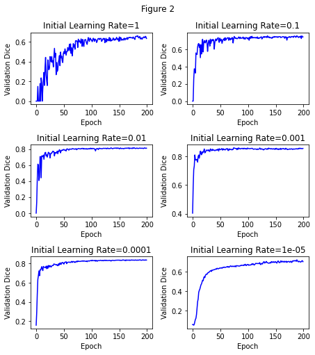

```python
# Plot the validation dice score with epoch for each initial learning rate figure
log_file_list = glob(os.path.join('./txt_path','*.txt'))

plt.figure(figsize=(6.4,2.4*math.ceil(len(lr_list)/2)))
plt.suptitle('Figure 2')
for i, init_lr in enumerate(lr_list):
    plt.subplot(math.ceil(len(lr_list)/2), 2, i+1)
    _, val_dice = get_loss_dice(log_file_list[idx])
    plt.plot([j for j in range(len(val_dice))], val_dice, 'b-')
    plt.xlabel('Epoch')
    plt.ylabel('Validation Dice')
    plt.title('Initial Learning Rate={}'.format(init_lr))
    plt.plot()
plt.tight_layout()
```

Thus, we set the initial learning rate as 0.001.

```python
init_lr = 0.001
```

#### 2.9.3 Epoch Number

Epoch number is an important hyperparameter while training. An epoch refers to the process of sending all data into the network to complete a forward calculation and back propagation. Epoch number determines the learning iteration times, which directly affects the learning effect. Too large number wastes too much training time and may lead to an over-fitting, while too small value could not guarantee the good learning result. Here we train the whole dataset for totally 200 epochs, and record the training and validation log for each epoch.

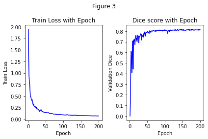

```python
train_loss, val_dice = get_loss_dice('results20211127-231719.txt')
# Create x value
epoch = [i+1 for i in range(len(train_loss))]
# Plot the train loss with epoch number figure
plt.figure()
plt.suptitle('Figure 3')
plt.subplot(1, 2, 1)
plt.plot(epoch, train_loss, 'b-')
plt.xlabel('Epoch')
plt.ylabel('Train Loss')
plt.title('Train Loss with Epoch')

# Plot the validation dice score with epoch number figure
plt.subplot(1, 2, 2)
plt.plot(epoch, val_dice, 'b-')
plt.xlabel('Epoch')
plt.ylabel('Validation Dice')
plt.title('Dice score with Epoch')
plt.tight_layout()
```

Thus, from the Figure 3, we can see before epoch=80, the dice has been steady, so epoch should be set as 80.

```python
epoch = 80
```

## 3 Evaluation

```python
aux = False  # inference time not need aux_classifier

weights_path =r'.\models\model_1.pth'  # path of model which is needed to be loaded

# get devices
device = torch.device("cuda:0" if torch.cuda.is_available() else "cpu")
print("using {} device.".format(device))

# create model
model = torch.hub.load('pytorch/vision:v0.10.0', 'deeplabv3_resnet50', pretrained=False, num_classes=4,
                       aux_loss=False)

# delete weights about aux_classifier
weights_dict = torch.load(weights_path, map_location='cpu')['model']
for k in list(weights_dict.keys()):
    if "aux" in k:
        del weights_dict[k]

# load weights
model.load_state_dict(weights_dict)
model.to(device)

test_path = './data/test/'  # path of test dataset folder
# load image
original_img = TestDataset(test_path)

# save the path of all the images in the test set
img_files = glob(os.path.join(test_path, 'image', '*.png'))

# save the path of all the masks for predicted masks
mask_files = []
for img_path in img_files:
    basename = os.path.basename(img_path)  # get the name of images
    mask_files.append(os.path.join(test_path, 'mask', basename[:-4] + '_mask.png'))

batch_size = 1  # now we predict the image one by one

num_workers = 0

all_img = DataLoader(dataset=original_img, num_workers=num_workers, batch_size=batch_size, shuffle=False)  # load the images

model.eval()  # model to evaluation mode

# for each image
for index, img in enumerate(all_img):
    with torch.no_grad():

        output = model(img.to(device))
        prediction = output['out'].argmax(1).squeeze(0)  # regularize the format
        prediction = prediction.to("cpu").numpy().astype(np.uint8)  # turning to the float

        cv2.imwrite(mask_files[index], prediction)  # save the mask
```

```
using cuda:0 device.
```

```
Using cache found in C:\Users\quchenyuan/.cache\torch\hub\pytorch_vision_v0.10.0
```

## 4 Submission

```python
def rle_encoding(x):
    '''
    *** Credit to https://www.kaggle.com/rakhlin/fast-run-length-encoding-python ***
    x: numpy array of shape (height, width), 1 - mask, 0 - background
    Returns run length as list
    '''
    dots = np.where(x.T.flatten() == 1)[0]
    run_lengths = []
    prev = -2
    for b in dots:
        if (b > prev + 1): run_lengths.extend((b + 1, 0))
        run_lengths[-1] += 1
        prev = b
    return run_lengths


def submission_converter(mask_directory, path_to_save):
    writer = open(os.path.join(path_to_save, "submission.csv"), 'w')
    writer.write('id,encoding\n')

    files = os.listdir(mask_directory)

    for file in files:
        name = file[:-4]
        mask = cv2.imread(os.path.join(mask_directory, file), cv2.IMREAD_UNCHANGED)

        mask1 = (mask == 1)
        mask2 = (mask == 2)
        mask3 = (mask == 3)

        encoded_mask1 = rle_encoding(mask1)
        encoded_mask1 = ' '.join(str(e) for e in encoded_mask1)
        encoded_mask2 = rle_encoding(mask2)
        encoded_mask2 = ' '.join(str(e) for e in encoded_mask2)
        encoded_mask3 = rle_encoding(mask3)
        encoded_mask3 = ' '.join(str(e) for e in encoded_mask3)

        writer.write(name + '1,' + encoded_mask1 + "\n")
        writer.write(name + '2,' + encoded_mask2 + "\n")
        writer.write(name + '3,' + encoded_mask3 + "\n")

    writer.close()
```

```python
submission_converter(r'.\data\test\mask',path_to_save='./CSV/')
```

# Report

## 1 Introduction

In this project, there are three network models that will be studied, but eventually, DeepLabV3 will be selected as the model for this task. The aim of our task is to segment a CMR image into four regions: the background, the left ventricle (LV), the right ventricle (RV) and the myocardium (Myo), which can save professionals’ time and improve accuracy. For the dataset, there are 200 CMR images and 200 respective ground truth mask images. It allocates 50% for training, 10% for validation and 40% for testing. The training dataset is used to train the network. The validation dataset is used to verify the learning effect of the model and tune hyperparameters. The test dataset is used for the input of the model to get the segmentation result. As for the choice of the loss function, the optimization algorithms, and hyperparameters, we will explain them in detail separately. By comparing segmentation results with the ground true masks, the generalization of the model could be tested. In conclusion, we get a model with a 0.86 dice score on the test dataset.

## 2 Implementation

In this part, the structure of Segnet, FCN and deeplabv3 will be introduced. Besides, some loss functions and optimizers will also be described, and it will show the optimal options.

### 2.1 Network

Three network models are built in this project, which are SegNet, FCN and DeepLabV3, and DeepLabV3 is selected as the most suitable one.

#### 2.1.1 SegNet

SegNet, an open resource project of image segmentation, is developed by a team of Cambridge University. Segmentation can be divided into two main parts: encoder and decoder[1]. An encoder is derived from VGG16 network model[2], which is mainly for the analysis of the information that objects contain, while the decoder is to map the analyzed information with the final images, which means that every pixel has a colour or label to show its object information. The encoder is a sequence of convolutional networks, which mainly consist of convolutional layers, pooling layers, and Batch-Normalization layers. Convolutional layers are for the capture of the local features of the image. Pooling layers are for the subsampling and the transformation of the same-size feature to the next layer. Batch-Normalization layers are for the distribution normalization of the training images, which accelerates the speed of learning. Encoder classifies and analyzes pixels of low-level local features to obtain high-level grammar meanings, while decoder collects these grammar meanings and labels same objects with their pixels to make all objects have their colours. Therefore, as the process of encoder obtains the approximate location information of all the objects, the decoder handles the process of labelling these objects with specific pixels. Decoder upsamples the minimized feature images, and then take actions of convolution with processed images to optimize geometric shapes of objects and to make up for the loss of details caused by the minimization of the pooling process[3]. However, due to the decoder structure in the Segnet, we expect that the inference time would take longer than the other two networks. There is one way to avoid the enormous number of parameters in the segnet, which is combining the squeeze net with the Segnet. It is also knowns as squeeze segnet[4]. It can significantly shorten the inference time in the segnet by making use of the advantages of the squeeze net. Therefore, we try to use this combination in our experiment section.

#### 2.1.2 FCN and DeepLabV3

Both FCN and DeepLabV3 have Resnet as the backbone. Resnet is divided into five stages[5]. Stage 0 is regarded as the preprocessing of input, and the last four stages are composed of bottlenecks[6]. Stage 1 contains three bottlenecks, and the remaining three stages include 4, 6 and 3 bottlenecks, respectively. After FCN is sampled by the previous stage of convolution, the deconvolution layer is used to sample the last feature map obtained by the convolution to restore it to the size of the input image. FCN classifies each pixel while retaining the spatial information of the original input image. Finally, the SoftMax classification loss is calculated through it pixel by pixel. FCNHead connects Layer3 and Layer4 and adjusts the channel value of the input feature layer or feature matrix through a 3*3 convolutional layer, reducing it to 1/4 of the original[6]. Finally, after dropout and a 1*1 convolutional layer, the channel of the feature layer is adjusted to the number of categories in the segmentation task. Bilinear interpolation restores the image to its original size. The auxiliary classifier prevents the error gradient from propagating to the shallow layers of the network.  
The structure of DeepLabV3 with Resnet backbone has an initial block, four layers, ASPP and the final block[7]. The input image passes through the initial block in 7*7 convolution and max pooling, and the output size is reduced by four times. About the four layers, the first two layers are the same as Resnet, and the latter two layers add astrous convolution. The astrous convolutions for layer 3 use fixed dilation but different dilations for layer 4 and the ASPP module. The astrous convolutions are present serially in layer 3 and layer 4 but parallelly in the ASPP module[8]. ASPP module includes five branches, one 1*1 convolution branch, three astrous convolution branches and one image pooling with 1*1 convolution branch. It contacts five branches and gets the result of the ASPP module. For the final block, there are two convolution layers and an up-sampling layer, which interpolates the number of classes of feature maps to the size of the input image using bilinear methods. DeepLabV3 has two main challenges in applying deep convolutional neural networks for semantic segmentation tasks[9]. The first challenge is that continued pooling and downsampling will reduce the resolution of features, which makes localization difficult. The second one is the existence of multi-scale targets. For the first challenge, DeepLabV3 proposed perforated convolution to improve the resolution of features while maintaining parameters and calculations. For the second challenge, DeepLabV3 proposed a multi-scale cascade or planetary convolution to improve the ASPP (Atrous Spatial Pyramid Pooling) module. Besides, the expanded convolutional layer with a large sampling rate will degenerate into a 1*1 convolutional layer when it cannot capture long-distance features due to the image boundary response. DeepLabV3 fuses the image-level features into the ASPP module to obtain the global context. In conclusion, DeepLabV3 encodes image-level global context features and further improves performance. DeeplabV3 is much better than the previous Deeplab, without post-processing of sense CRF, and has achieved state of art performance on the Pascal VOC 2012 semantic image segmentation benchmark[9]. For the neural network architectures, we decide to use DeepLabV3 as our final model, because after our experiments, we find that the dice of DeepLabV3 after all models converge is highest, which means that the performance of this model is best. At the same time, the running time and GPU memory used of it are also only slightly above these of e segnet. These will be discussed more in the Experiment module.

### 2.2 Loss Function

#### 2.2.1 Cross-Entropy

Cross-entropy can be used in most segmentation situations[10]. Compared with other loss functions, it has two significant advantages: 1. It can measure subtle differences 2. Convex optimization function, which is convenient for using the gradient descent method to find the optimal solution. but its main drawback is that when it comes to segmenting the foreground and background, in another word the amount of foreground pixels is extremely less than that of background pixels, the model will deeply depend on the background, which leads to bad training results. To avoid that, we chose to use Cross-Entropy and Dice in our work, which works better than using them singly.

#### 2.2.2 Dice Loss

Dice Loss is a function to measure the similarity of sets, usually used to compute the similarity degree of two samples[10]. For binary classification, Target segmentation images only have two values, therefore, it is efficient to ignore background pixels. Focused on the target parts that are being detected, the more similarities prediction results with true labels have, the higher the Dice coefficient will be, and the smaller the Dice Loss will be. Meanwhile, Dice Loss works well when target samples are extremely unbalanced. Though Dice Loss will be largely due to the unsuccessful segmentation when targets are small, which has a negative influence on the Back Propagation and makes the training unstable, it performed pretty well as our loss function. Therefore, we also used Cross-Entropy in our work to get better performance.

#### 2.2.3 Focal Loss

Focal Loss was introduced in the paper written by the team of HeKaiming, which was to solve the problem caused by the unbalance of the hard samples and easy samples[11]. In one-stage objects detection, the negative samples and positive samples are heavily unbalanced, thus the loss function heavily decreases the proportion of the amount of simple negative samples in the training process, which also can be comprehended as difficult sample mining. For positive samples, the higher the probability of the output gets, the smaller the loss becomes. For negative samples, the lower the probability of the output gets, the smaller the loss becomes. To solve the unbalanced problem of negative samples and positive samples, Focal Loss chose to minimize the loss of samples with high confidence. However, its training results scored less than Dice loss in our work.

### 2.3 Optimizer

After getting loss function, our task begins to minimize it. The process of minimizing loss is so-called optimization. Here we introduce some usual optimizers and compare them from various aspects.

#### 2.3.1 SGD

SGD has no conception of momentum, and its main drawback is that its slow descent speed, and it may continuously oscillate on both sides of the gully, staying at a local optimum[12]. Meanwhile, it is difficult to select the learning rate properly. Therefore, we did not choose this method for our work.

#### 2.3.2 Adam

Adam can be seen as the combination of RmSprop and Momentum. Like RMSprop which uses exponential moving average for second-order momentum, Adam also uses exponential moving average for first-order momentum[13]. Its core philosophy is simple and straight, since the square of the nearest gradient shows the information we gain from each weight, we can divide it by its point to make sure that even the weight with the slowest change can make contributions.

#### 2.3.3 AdamW

To use AdamW, we need to understand weight attenuation and L2 regularization. L2 regularization is a classic method for reducing over-fitting[14]. It adds a penalty term which consists of the sum of squares of all weights of the model to the loss function and multiplies with a specific hyperparameter to control the penalty intensity. For the ladder function in the optimizer, we only need to use the gradient to correct the parameter and not use the value of the parameter itself at all. As for weight decay, we can simply implement the weight attenuation before the optimizer[15]. Therefore, we decided to choose AdamW as our optimizer.

## 3 Experiment

For the best performance of our task, we need to find the best model and parameters fitting to our task. Before loading the data, we need to do preprocessing to our dataset for better training performance, then we choose the best model, loss function and optimizer for our task. After that, what we need to do left is adjust the hyperparameters for best efficiency and performance.

### 3.2 Performance of the three Network (via Dice Score)

Now we are going to discuss the model selection. The table below shows the performance of different models in fixed iterations.

| Network/Iterations | 30 | 100 | 200 |
| --- | --- | --- | --- |
| Squeeze SegNet | 0.759 | 0.823 | 0.827 |
| FCN_resnet50 | 0.802 | 0.858 | 0.862 |
| DeepLabV3_resnet50 | 0.812 | 0.868 | 0.871 |

DeepLabV3_resnet50 obtains the highest dice score. It outperforms FCN_resnet50 and SegNet. The improved DeepLabv3_resnet50 algorithm has the best effect among the three network models. After the maximum number of iterations, the final dice score on the validation set can reach 0.87134. (Although there is still a certain gap with the official data released by PyTorch, it only reaches 93% of the official data level)[16].

| Network | Forward Pass(ms) | Backward Pass(ms) | GPU Training Memory(MB) | GPU inference Memory(MB) | Model Size(MB) |
| --- | --- | --- | --- | --- | --- |
| Squeeze SegNet | 140 | 170 | 5500 | 1002 | 75 |
| DeeplabV3_resnet50 | 151 | 180 | 5600 | 1453 | 80 |
| FCN_resnet50 | 300 | 357 | 9630 | 1700 | 525 |

Squeeze SegNet is a lite version of the SegNet as we mentioned before. Therefore, the model size is much smaller than FCN and slightly smaller than DeeplabV3. Above all, DeepLabV3 has the best performance among these three models, while the training time and GPU memory used are just a little higher than squeeze Segnet, therefore, we chose DeepLabV3 as our model.

### 3.3 Performance of different Loss Functions (via Dice Score)

| Network/Loss Functions | Dice Loss + Cross Entropy Loss (Dice Score) | Dice Loss (Dice Score) | Cross Entropy Loss (Dice Score) | Focal Loss (Dice Score) |
| --- | --- | --- | --- | --- |
| DeeplabV3_resnet50 | 0.871 | 0.852 | 0.856 | 0.823 |

### 3.4 Performance of different Optimizer (via Dice Score)

| Network/optimizer | Adam | SGD | AdamW |
| --- | --- | --- | --- |
| DeeplabV3_resnet50 | 0.864 | 0.859 | 0.871 |

### 3.5 Hyperparameter

We could use different learning rates, batch sizes, epoch numbers, and other different hyperparameters during training. Here we try separate ways and values with respect to each of them and compare the dice score performance on the validation set.

### 3.5.1 Batch-Size

An epoch refers to the process of sending all data into the network to complete a forward calculation and backpropagation. Since an epoch is often too large for the computer to load, we will divide it into several smaller batches, while the batch size is the number of training samples in each batch. It could determine the speed and accuracy of convergence. Too small value leads the speed of convergence too slow, while a too-large value may disturb the direction and accuracy of convergence. What else we need to consider is memory efficiency and memory capacity and find the best balance between them. Here we try different values from 2 to 10 for batch size and show the validation result for each of them as Figure 1. As we can see, when a batch size is a small number, it is hard to converge in a limited epoch number. When a batch size is a considerable number, the number of iterations required to run an epoch is reduced, which means less time is needed for training. However, the iteration it takes is increased to achieve the same accuracy for the neural network. We could find that when batch size is equal to 6, the convergence speed and result reach a relatively good point, while the training efficiency is also acceptable.

### 3.5.2 Learning Rate

As an important hyperparameter in deep learning, the learning rate determines whether the objective function can converge to a local minimum and when to converge to the minimum. A suitable learning rate can make the objective function converge to a local minimum in a suitable time. Here we try the different initial learning rates from 0.00001 to 1 for optimizer and show the validation result for each of them. As we can see in Figure 2, a too-large learning rate could lead to non-convergence, while a too-small learning rate will converge to a local minimum, which leads to a bad learning effect. We could see that 0.001 is an appropriate initial learning rate for training our model, which has appropriate convergence speed and result.

### 3.5.3 Epoch Number

The epoch number is an important hyperparameter during training. Epoch number determines the learning iteration times, which directly affects the learning effect. A too substantial number wastes too much training time and may lead to an over-fitting, while too small value could not guarantee a good learning result. Here we train the whole dataset for 200 epochs and record the training and validation log for each epoch as Figure 3 shows. As we can see, as the epoch number increases, the training loss keeps going down but changes from steep to gentle, finally coming to convergence, while the validation dice score has already converged at around 80 epochs. As a result, for the model we selected and this training set, 80 epochs are enough for training to get the expected result.

## 4 Conclusion

- We chose DeepLabV3 as our model after comparing it with FCN and Segnet, because it has the best performance and good training consumption. It is an improved algorithm from FCN and more suitable for this task than Segnet.
- Dice + cross-entropy loss function is picked as our loss function because its performance is the best. It is a combination method of the dice loss function and the cross-entropy loss function, which is suitable for segmentation tasks and avoids dependence on the background.
- For optimizer, AdamW is chosen in the end. Adam has better performance than SGD and AdamW is even the improved optimizer to Adam. Hence, we choose AdamW as our optimizer.
- For the hyperparameters, we choose 6 as our batch size because it is not too small to reduce the speed and too large to disturb the direction and accuracy. 0.001 is chosen as our initial learning rate because when we choose this initial learning rate, we get a suitable number of iterations to converge the model and the highest dice score. Based on the batch size and initial learning rate, we choose 80 as our epoch number, in other words, iterations. Because that is already big enough to make the model converge.
- The performance of our model is 86 per cent on the testing set. Due to the small training set, we suppose that the performance of our model is great, while the training time is short and GPU memory is low.

## Reference

[1] https://arxiv.org/pdf/1511.00561.pdf SegNet: A Deep Convolutional Encoder-Decoder Architecture for Image Segmentation

[2] https://www.oreilly.com/radar/visualizing-convolutional-neural-networks/

[3] https://arxiv.org/abs/1505.04366 Learning Deconvolution Network for Semantic Segmentation

[4] https://iq.opengenus.org/resnet50-architecture/

[5] https://arxiv.org/abs/1711.05491 Squeeze-SegNet: A new fast Deep Convolutional Neural Network for Semantic Segmentation

[6]https://github.com/pytorch/vision/blob/main/torchvision/models/segmentation/fcn.py

[7]https://paperswithcode.com/method/deeplabv3#:~:text=DeepLabv3%20is%20a%20semantic%20segmentation,by%20adopting%20multiple%20atrous%20rates.

[8] https://towardsdatascience.com/review-deeplabv3-atrous-convolution-semantic-segmentation-6d818bfd1d74

[9] https://towardsdatascience.com/deeplabv3-c5c749322ffa

[10] https://stats.stackexchange.com/questions/321460/dice-coefficient-loss-function-vs-cross-entropy

[11] https://amaarora.github.io/2020/06/29/FocalLoss.html

[12] http://proceedings.mlr.press/v102/kervadec19a/kervadec19a.pdf

[13] https://optimization.cbe.cornell.edu/index.php?title=Stochastic_gradient_descent

[14] https://mlfromscratch.com/optimizers-explained/#/

[15] https://www.fast.ai/2018/07/02/adam-weight-decay/

[16] https://www.mdpi.com/1424-8220/21/4/1167/pdf

[17] https://medium.com/deep-learning-demystified/https-medium-com-deep-learning-demystified-understanding-optimizers-313b787a69fe